# Tibble Joins

## Resources

Video lecture:

- [Tibble Joins with dplyr](https://youtu.be/YAdX9MVRY1c)

Other resources, in addition to the notes below:

- A comprehensive overview can be found in the [“Relational Data” chapter](https://r4ds.had.co.nz/relational-data.html) in “R for Data Science”.
- Concise resources:
  - “Two-table verbs” [vignette](https://cran.r-project.org/web/packages/dplyr/vignettes/two-table.html) gives a concise overview of tibble joins with dplyr.
  - [Jenny’s Join Cheatsheet](https://stat545.com/join-cheatsheet.html) for a quick reference to joins.
- Revisit the [dplyr cheatsheet](https://rstudio.com/wp-content/uploads/2015/02/data-wrangling-cheatsheet.pdf) for all these concepts packed onto a sheet of paper.

## Overview of join functions

**Note:** In order to merge two tibbles, you need to have an identifier variable that has unique values for every row of observations in both tibbles.

Create two sample tibbles:

```r
# First tibble
df1 <- tibble(ID = 1:3,
              Name = c("Sophie", "Josh","Alex"))

# Second tibble
df2 <- tibble(ID = 2:4,
              Age = c(20,50,31))
```

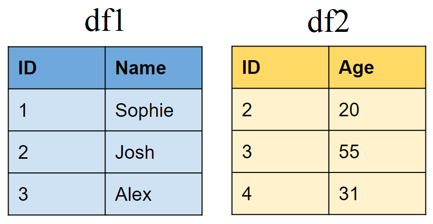

## Mutating joins

### Join matching rows from df2 to df1

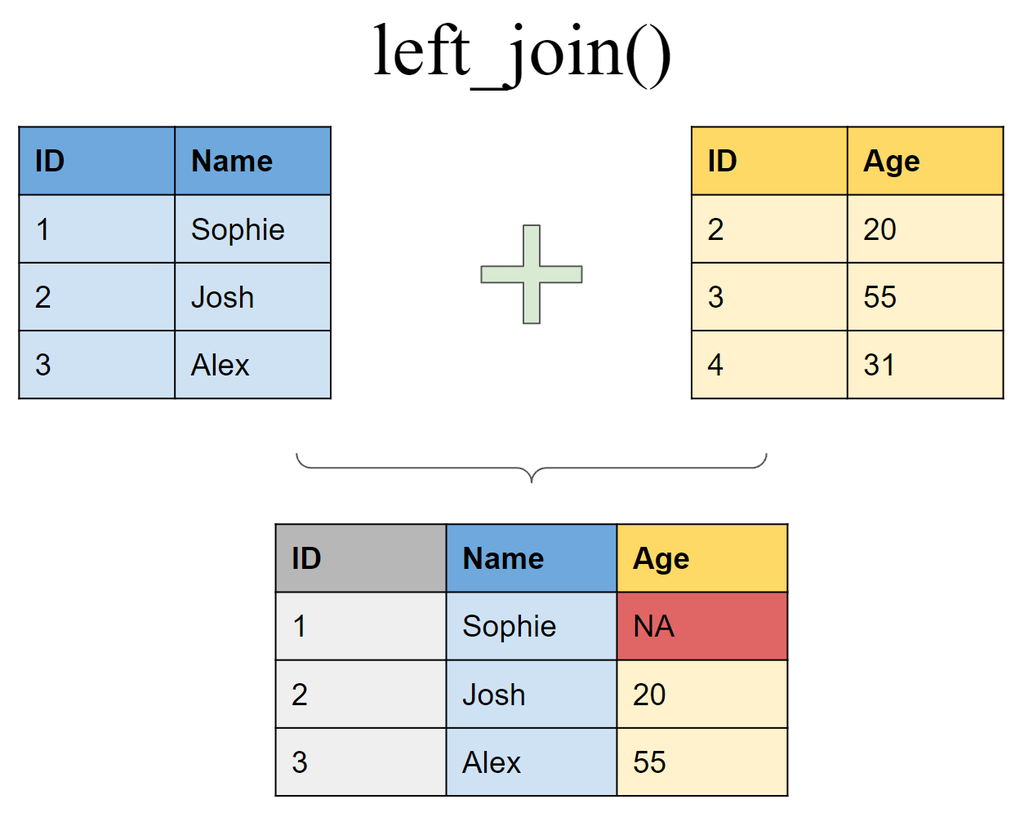

```r
left_join(df1, df2, by = "ID")
```

```
## # A tibble: 3 × 3
##      ID Name     Age
##   <int> <chr>  <dbl>
## 1     1 Sophie    NA
## 2     2 Josh      20
## 3     3 Alex      50
```

### Join matching rows from df1 to df2

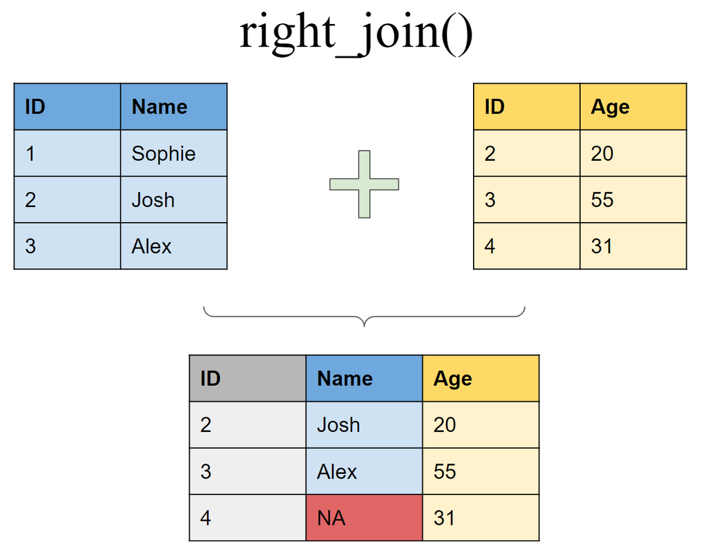

```r
right_join(df1, df2, by = "ID")
```

```
## # A tibble: 3 × 3
##      ID Name    Age
##   <int> <chr> <dbl>
## 1     2 Josh     20
## 2     3 Alex     50
## 3     4 <NA>     31
```

### Retain only rows present in both sets

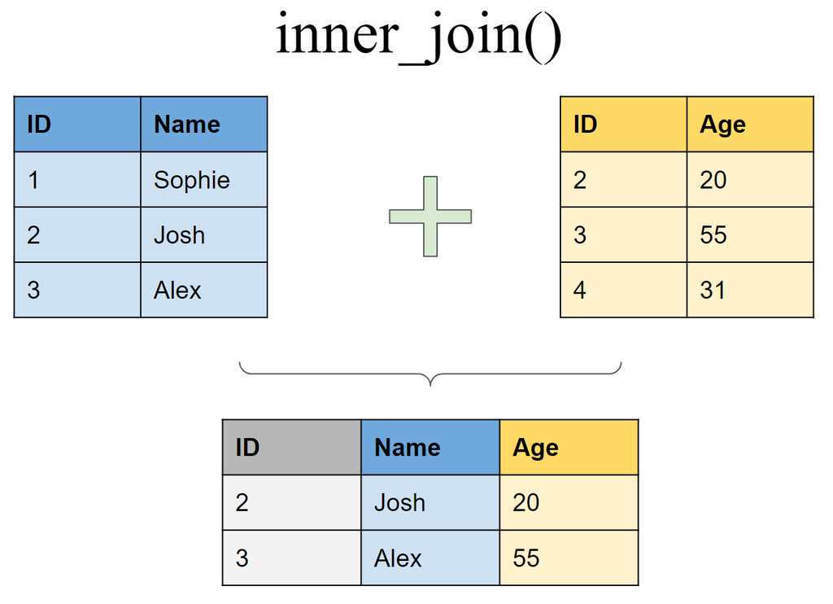

```r
inner_join(df1, df2, by = "ID")
```

```
## # A tibble: 2 × 3
##      ID Name    Age
##   <int> <chr> <dbl>
## 1     2 Josh     20
## 2     3 Alex     50
```

### Retain all values, all rows

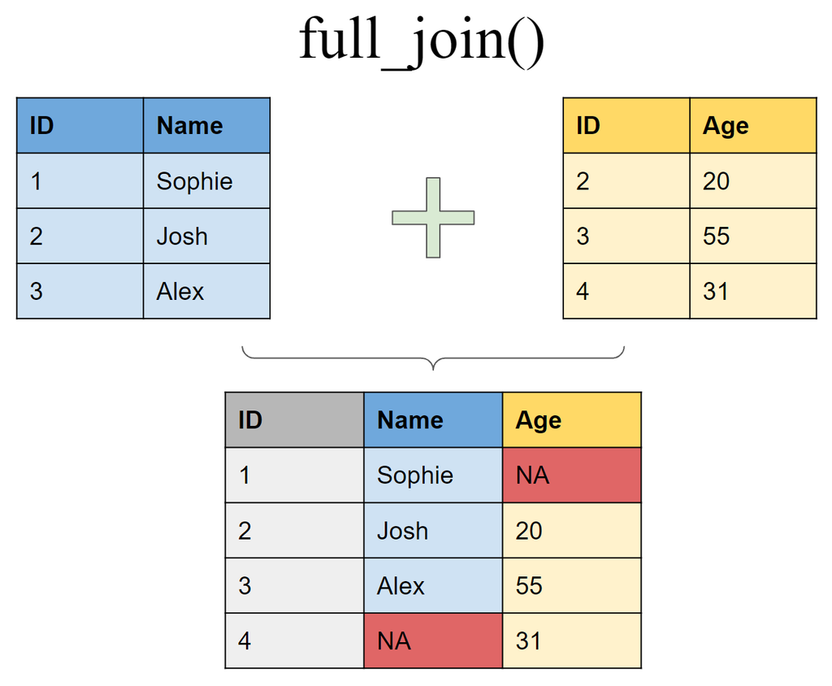

```r
full_join(df1, df2, by = "ID")
```

```
## # A tibble: 4 × 3
##      ID Name     Age
##   <int> <chr>  <dbl>
## 1     1 Sophie    NA
## 2     2 Josh      20
## 3     3 Alex      50
## 4     4 <NA>      31
```

## Filtering joins

### Retain all rows in df1 that have a match in df2

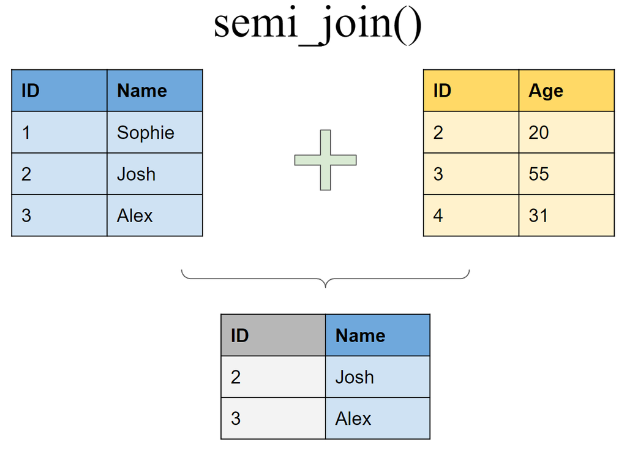

```r
semi_join(df1, df2, by = "ID")
```

```
## # A tibble: 2 × 2
##      ID Name
##   <int> <chr>
## 1     2 Josh
## 2     3 Alex
```

### Retain all rows in df1 that do not have a match in df2

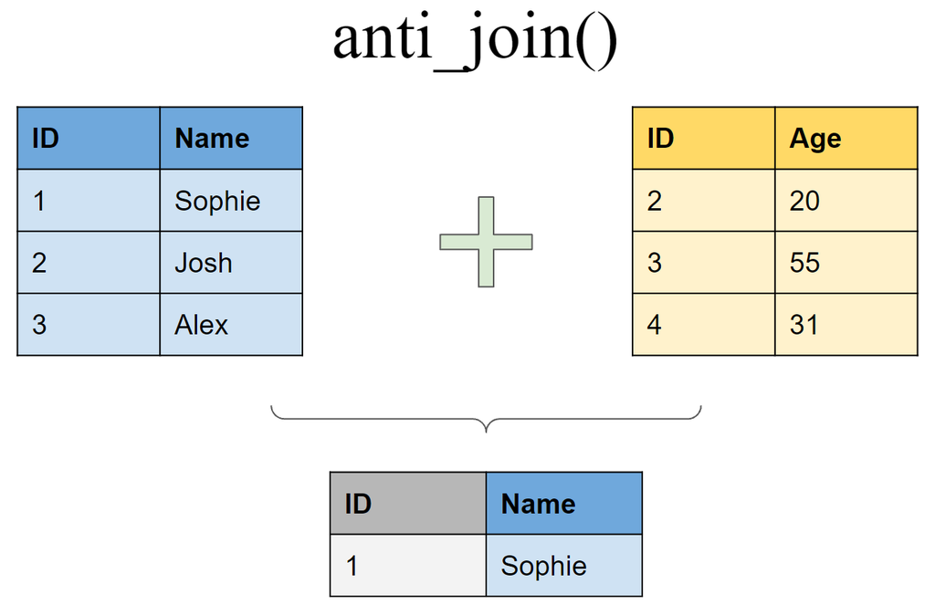

```r
anti_join(df1, df2, by = "ID")
```

```
## # A tibble: 1 × 2
##      ID Name
##   <int> <chr>
## 1     1 Sophie
```

## Binding

### Append df2 to df1 as new rows

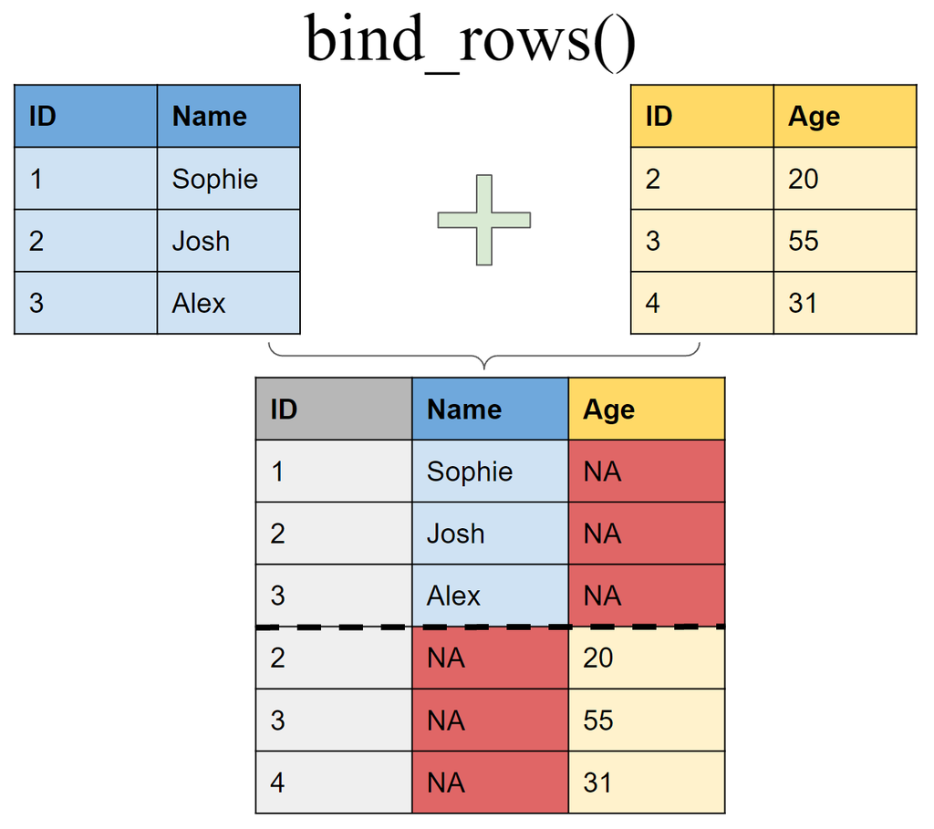

```r
bind_rows(df1, df2)
```

```
## # A tibble: 6 × 3
##      ID Name     Age
##   <int> <chr>  <dbl>
## 1     1 Sophie    NA
## 2     2 Josh      NA
## 3     3 Alex      NA
## 4     2 <NA>      20
## 5     3 <NA>      50
## 6     4 <NA>      31
```

### Append df2 to df1 as new columns

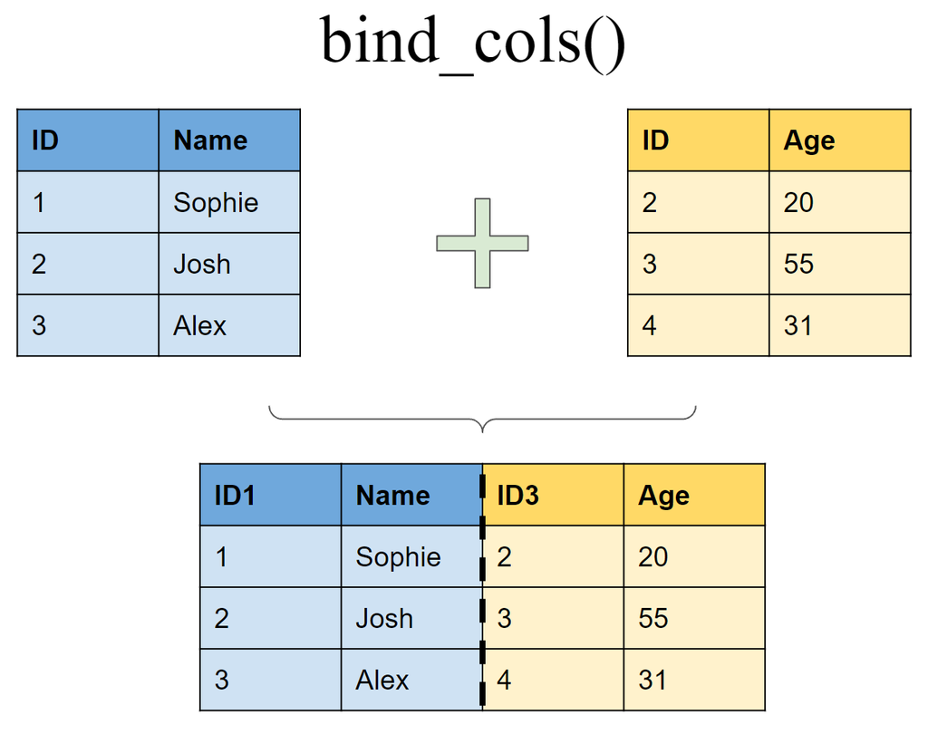

```r
bind_cols(df1, df2)
```

```
## # A tibble: 3 × 4
##   ID...1 Name   ID...3   Age
##    <int> <chr>   <int> <dbl>
## 1      1 Sophie      2    20
## 2      2 Josh        3    50
## 3      3 Alex        4    31
```

## Joining multiple (>2) tibbles

Create a third tibble

```r
df3 <- tibble(ID = 1:5,
              Height = c(175,167,190,155,160))
```

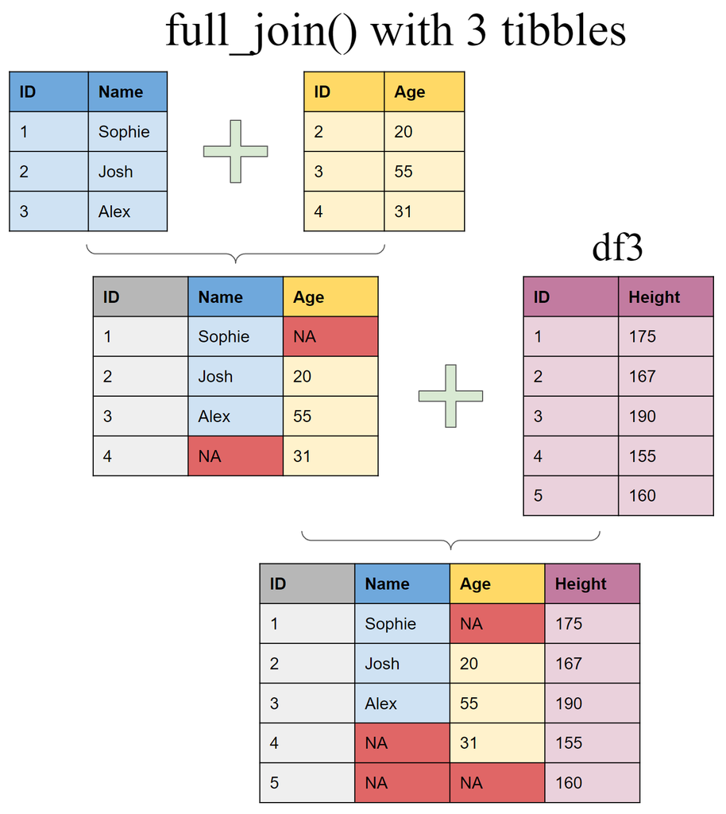

Use piping operator (%>%) to layer multiple join functions

```r
full_join(df1, df2, by = "ID") %>%
  full_join(df3, by = "ID")
```

```
## # A tibble: 5 × 4
##      ID Name     Age Height
##   <int> <chr>  <dbl>  <dbl>
## 1     1 Sophie    NA    175
## 2     2 Josh      20    167
## 3     3 Alex      50    190
## 4     4 <NA>      31    155
## 5     5 <NA>      NA    160
```

## Joining tibbles on multiple conditions

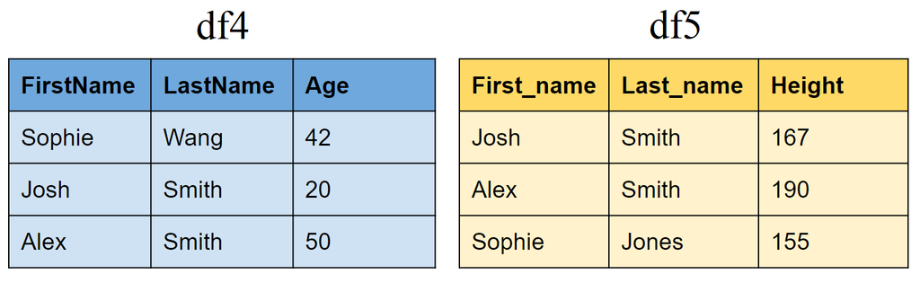

Create two new tibbles df4 and df5

```r
df4 <- tibble(FirstName = c("Sophie", "Josh","Alex"),
              LastName=c("Wang","Smith","Smith"),
              Age = c(42,20,50))

df5 <- tibble(First_name = c("Josh","Alex","Sophie"),
              Last_name=c("Smith","Smith","Jones"),
              Height = c(167,190,155))
```

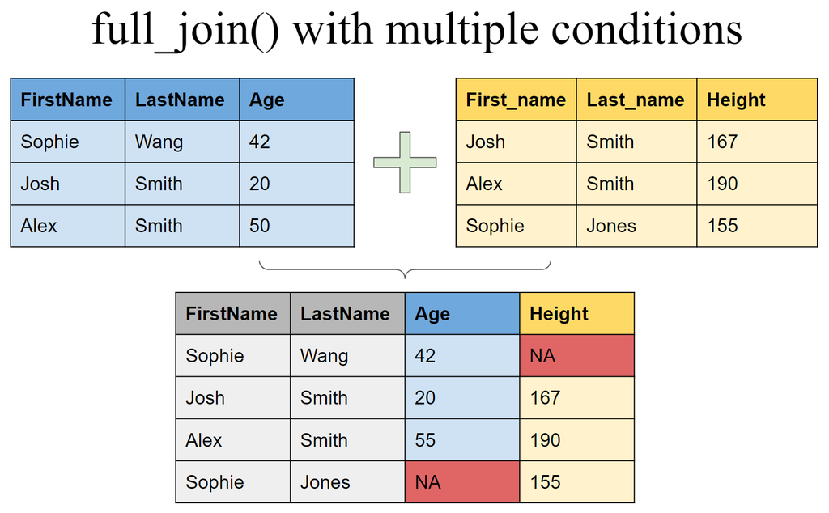

```r
full_join(df4, df5, by = c("FirstName" = "First_name", "LastName" = "Last_name"))
```

```
## # A tibble: 4 × 4
##   FirstName LastName   Age Height
##   <chr>     <chr>    <dbl>  <dbl>
## 1 Sophie    Wang        42     NA
## 2 Josh      Smith       20    167
## 3 Alex      Smith       50    190
## 4 Sophie    Jones       NA    155
```

## Set operations

Create sample tibbles

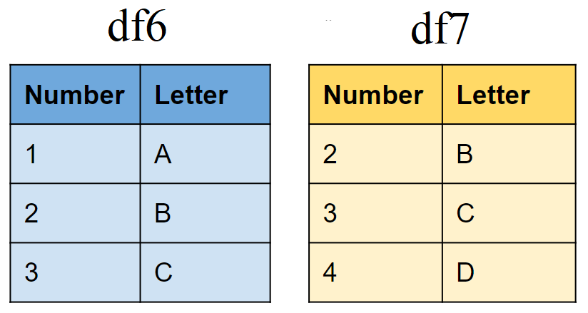

```r
# First tibble
df6 <- tibble(Number = 1:3,
              Letter = c("A", "B","C"))

# Second tibble
df7 <- tibble(Number = 2:4,
              Letter = c("B","C","D"))
```

### Include rows that appear in both tibbles

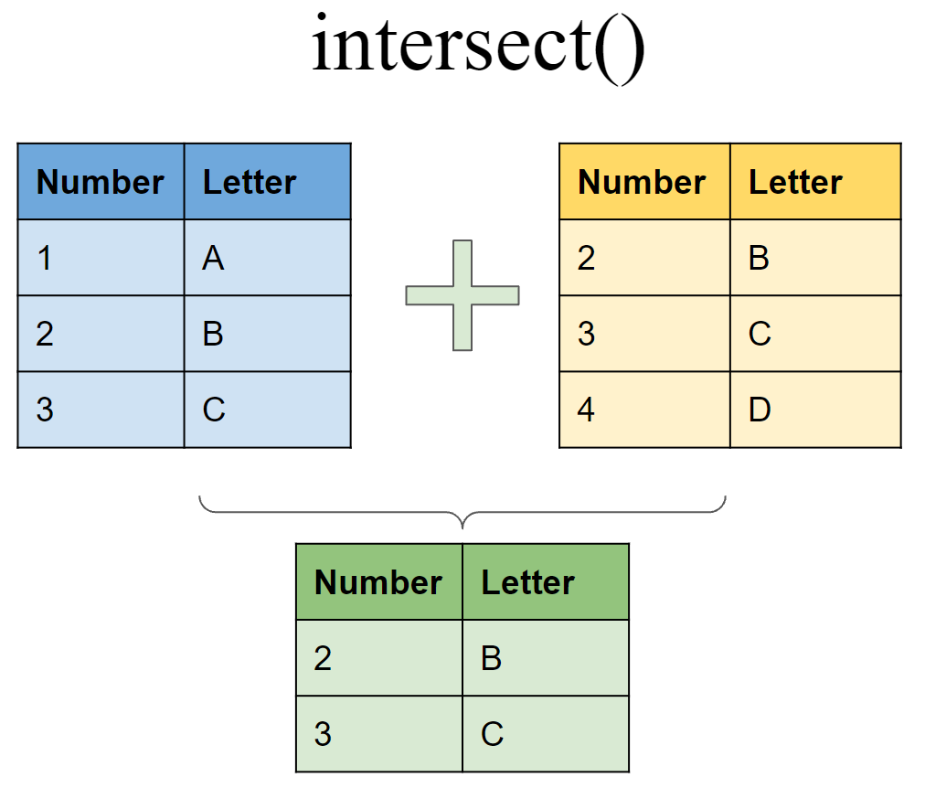

```r
intersect(df6, df7)
```

```
## # A tibble: 2 × 2
##   Number Letter
##    <int> <chr>
## 1      2 B
## 2      3 C
```

### Include rows that appear in either or both tibbles

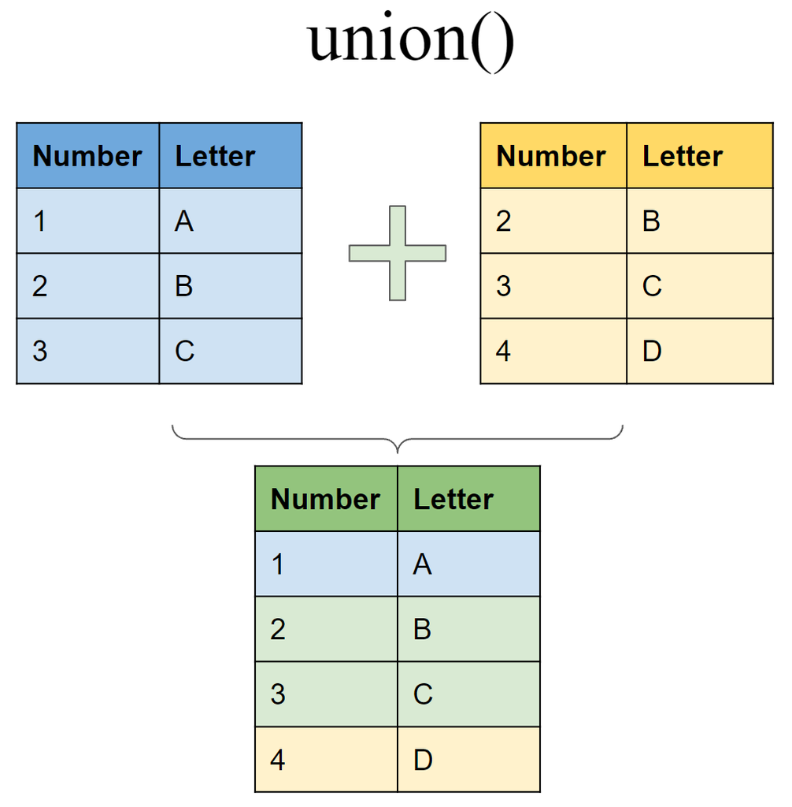

```r
union(df6, df7)
```

```
## # A tibble: 4 × 2
##   Number Letter
##    <int> <chr>
## 1      1 A
## 2      2 B
## 3      3 C
## 4      4 D
```

### Include rows that appear in one df but not another

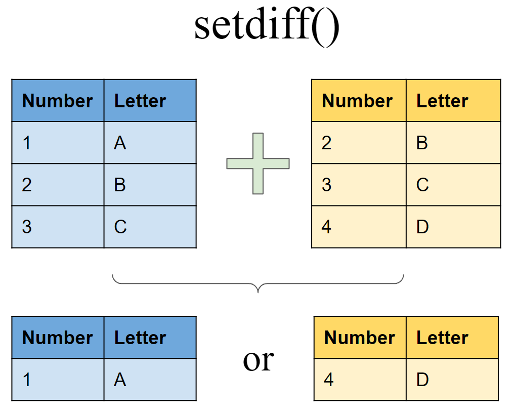

Include rows that appear in df6 but not in df7

```r
setdiff(df6, df7)
```

```
## # A tibble: 1 × 2
##   Number Letter
##    <int> <chr>
## 1      1 A
```

Include rows that appear in df7 but not in df6

```r
setdiff(df7, df6)
```

```
## # A tibble: 1 × 2
##   Number Letter
##    <int> <chr>
## 1      4 D
```

## Joining tibbles with different types of variables

You can also join tibbles with sets of predictions:

```r
set.seed(1)
x <- rnorm(5)
model1 <- tibble(x = x, yhat = 2.1 + 3.2 * x)
model2 <- tibble(x = x, yhat = 1.5 + 2.9 * x)
left_join(model1, model2, by = "x")
```

```
## # A tibble: 5 × 3
##        x  yhat.x yhat.y
##    <dbl>   <dbl>  <dbl>
## 1 -0.626  0.0953 -0.317
## 2  0.184  2.69    2.03
## 3 -0.836 -0.574  -0.923
## 4  1.60   7.20    6.13
## 5  0.330  3.15    2.46
```

## Your turn: learning tibble joins

We think the best way to learn the basics of tibble joins from here is to work through the corresponding part of Worksheet A5.

There will be some class time to go over solutions if you got stuck on any questions.

### Attributions

Written by Albina Gibadullina, reviewed by Vincenzo Coia.